# R Notebook

Question 1. Load the data, clean_names() and explore it.

```r
library(tidyverse)

clean_names <- read.csv("20190928-items.csv")

clean_names %>%
  skimr::skim()
```

```
── Data Summary ────────────────────────
                           Values
Name                       Piped data
Number of rows             792
Number of columns          9
_______________________
Column type frequency:
  character                7
  numeric                  2
________________________
Group variables            None
```

|  | skim_variable | n_missing | complete_rate | min | max | empty | n_unique | whitespace |
| --- | --- | --- | --- | --- | --- | --- | --- | --- |
| 1 | asin | 0 | 1 | 10 | 10 | 0 | 792 | 0 |
| 2 | brand | 0 | 1 | 4 | 8 | 0 | 10 | 0 |
| 3 | title | 0 | 1 | 19 | 200 | 0 | 785 | 0 |
| 4 | url | 0 | 1 | 60 | 97 | 0 | 792 | 0 |
| 5 | image | 0 | 1 | 87 | 87 | 0 | 719 | 0 |
| 6 | reviewUrl | 0 | 1 | 49 | 49 | 0 | 792 | 0 |
| 7 | prices | 0 | 1 | 0 | 19 | 215 | 448 | 0 |

|  | skim_variable | n_missing | complete_rate | mean | sd | p0 | p25 | p50 | p75 | p100 | hist |
| --- | --- | --- | --- | --- | --- | --- | --- | --- | --- | --- | --- |
| 1 | rating | 0 | 1 | 3.607576 | 0.6687295 | 1 | 3.2 | 3.7 | 4.00 | 5 | ▁▁▅▇▂ |
| 2 | totalReviews | 0 | 1 | 104.231061 | 166.2425030 | 1 | 7.0 | 31.5 | 122.25 | 984 | ▇▁▁▁▁ |

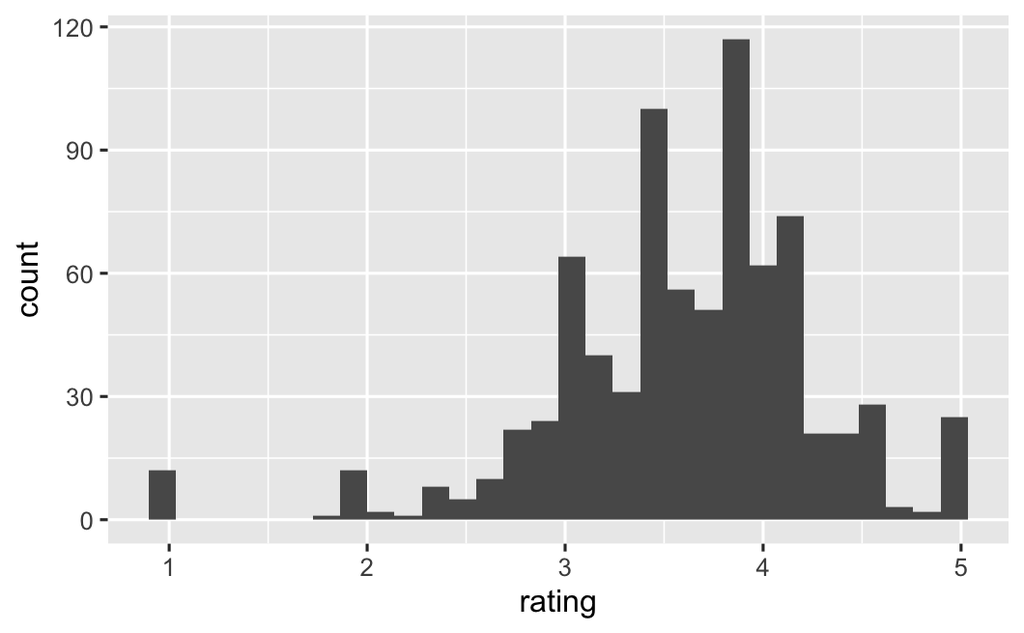

```r
clean_names %>%
  ggplot(aes(x = rating)) +
  geom_histogram()
```

`data is negative scweked` `unimodel`

Question 2. Find the brand with the highest numbers of phones in the dataset.

```r
clean_names %>%
  group_by(brand) %>%
  summarise(count = n()) %>%
  arrange(desc(count)) %>%
  head(1)
```

| brand | count |
| --- | --- |
| Samsung | 397 |

```r
NA
```

Question 3. For your top brand, plot the distribution of phone ratings as a probability density, overlaying a fitted normal distribution. Do you think the normal distribution provides a good model of these ratings? Hint

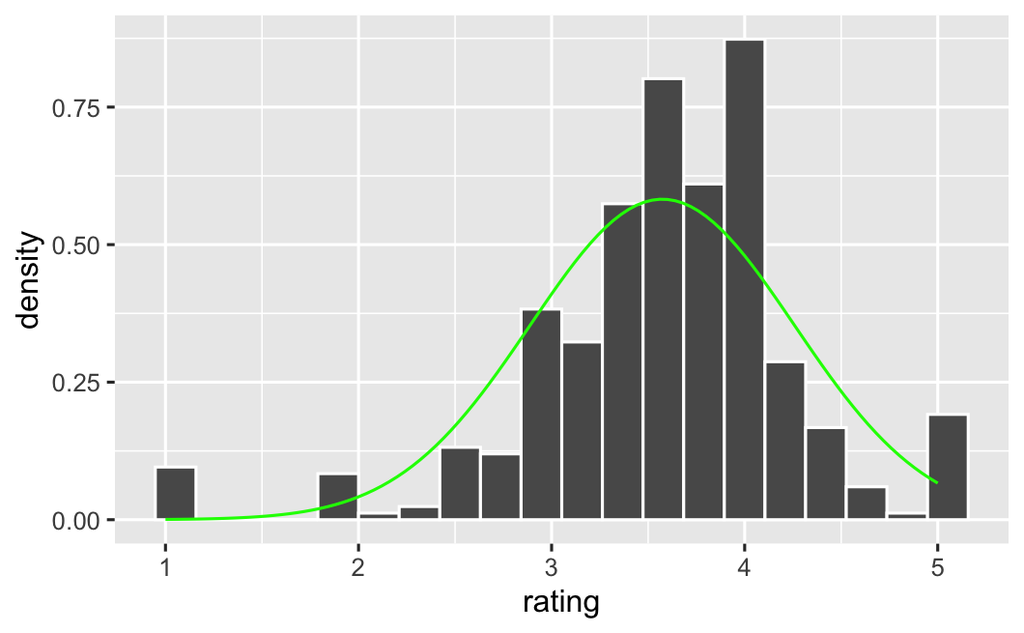

mean = 3.5733 sd = 0.6

`not the best lots of stuff left out!` `stops before end of rating`

Question 4. We can be more quantitative in comparing the distribution of top brand ratings with a normal distribution. You calculated the mean() and sd() of your distribution in an earlier question. Use these values to calculate the proportions of ratings within one-, two- and three standard deviations of the mean. Compare these proportions with those you expect for a normal distribution.

This is what we expect =

```r
pnorm(1) - pnorm(-1)
```

```
[1] 0.6826895
```

```r
samsung %>%
 filter(rating >= samsung_stats$mean - samsung_stats$sd) %>%
 filter(rating <= samsung_stats$mean + samsung_stats$sd) %>%
 summarise(prop_within_1sd = n() / nrow(samsung))
```

| prop_within_1sd |
| --- |
| 0.7934509 |

```r
NA
```

so in 1 SD - we have more data than the three sigma rule of `0.6826895` = 0.7934509

```r
samsung %>%
 filter(rating >= samsung_stats$mean - samsung_stats$sd) %>%
 filter(rating <= samsung_stats$mean + samsung_stats$sd) %>%
 summarise(prop_within_1sd = n() / nrow(samsung))
```

just me looking at stuff

[output not shown]

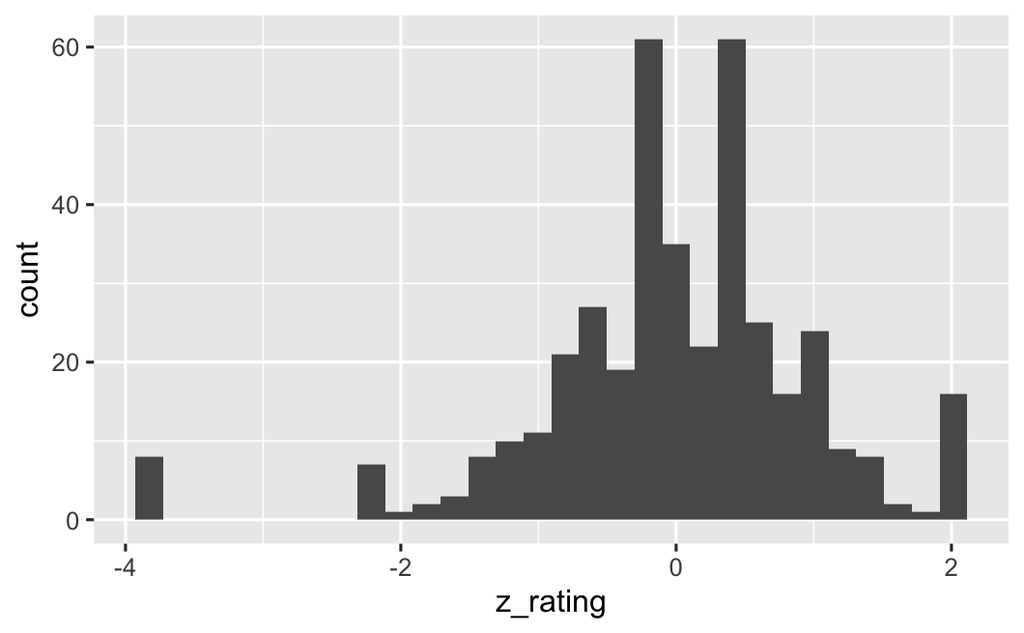

```r
standard_scaled %>%
  ggplot(aes(x = z_rating)) +
  geom_histogram()
```